# Assignment 5 - Decision Tree

## Dipannita Banerjee

### Bangalore Group 1

#### Regression using Decision Tree

Importing required libraies

```python
import os
import pandas as pd
```

Importing the dataset

```python
os.chdir(r'C:\Users\IBM_ADMIN\Music\UC\Module - Machine learning\Module 5\Assignment 5')
```

```python
asg=pd.read_csv("petrol_consumption.csv")
```

```python
asg.head()
```

|  | Petrol_tax | Average_income | Paved_Highways | Population_Driver_licence(%) | Petrol_Consumption |
| --- | --- | --- | --- | --- | --- |
| 0 | 9.0 | 3571 | 1976 | 0.525 | 541 |
| 1 | 9.0 | 4092 | 1250 | 0.572 | 524 |
| 2 | 9.0 | 3865 | 1586 | 0.580 | 561 |
| 3 | 7.5 | 4870 | 2351 | 0.529 | 414 |
| 4 | 8.0 | 4399 | 431 | 0.544 | 410 |

Checking description of data set

```python
asg.describe()
```

|  | Petrol_tax | Average_income | Paved_Highways | Population_Driver_licence(%) | Petrol_Consumption |
| --- | --- | --- | --- | --- | --- |
| count | 48.000000 | 48.000000 | 48.000000 | 48.000000 | 48.000000 |
| mean | 7.668333 | 4241.833333 | 5565.416667 | 0.570333 | 576.770833 |
| std | 0.950770 | 573.623768 | 3491.507166 | 0.055470 | 111.885816 |
| min | 5.000000 | 3063.000000 | 431.000000 | 0.451000 | 344.000000 |
| 25% | 7.000000 | 3739.000000 | 3110.250000 | 0.529750 | 509.500000 |
| 50% | 7.500000 | 4298.000000 | 4735.500000 | 0.564500 | 568.500000 |
| 75% | 8.125000 | 4578.750000 | 7156.000000 | 0.595250 | 632.750000 |
| max | 10.000000 | 5342.000000 | 17782.000000 | 0.724000 | 968.000000 |

Checking for NULL and NA in the data set

```python
asg.isnull().sum()
```

```
Petrol_tax                      0
Average_income                  0
Paved_Highways                  0
Population_Driver_licence(%)    0
Petrol_Consumption              0
dtype: int64
```

```python
asg.isna().sum()
```

```
Petrol_tax                      0
Average_income                  0
Paved_Highways                  0
Population_Driver_licence(%)    0
Petrol_Consumption              0
dtype: int64
```

Checking shape of the data

```python
asg.shape
```

```
(48, 5)
```

Spliting the data set in to training and testing sets

```python
from sklearn.model_selection import train_test_split
```

```python
X_train, X_test, Y_train, Y_test = train_test_split(asg.drop('Petrol_Consumption', axis=1), asg['Petrol_Consumption'],\
                                                    test_size=0.15, random_state=123)
```

Importing Decision Tree Regressor and fit the model to the training data

```python
from sklearn.tree import DecisionTreeRegressor
```

```python
tree = DecisionTreeRegressor(max_depth=2)
```

```python
tree.fit(X_train, Y_train)
```

```
DecisionTreeRegressor(criterion='mse', max_depth=2, max_features=None,
           max_leaf_nodes=None, min_impurity_decrease=0.0,
           min_impurity_split=None, min_samples_leaf=1,
           min_samples_split=2, min_weight_fraction_leaf=0.0,
           presort=False, random_state=None, splitter='best')
```

Make predictions and evaluate output

```python
predictions = tree.predict(X_test)
```

Checking the 10 predictions and actual values

```python
predictions[:10]
```

```
array([676.        , 676.        , 573.69230769, 676.        ,
       453.7       , 676.        , 676.        , 453.7       ])
```

```python
Y_test[:10]
```

```
18    865
13    508
26    577
31    554
10    580
40    587
39    968
8     464
Name: Petrol_Consumption, dtype: int64
```

We can see predictions are not accurate . Let's check accuracy of the model

```python
from sklearn.metrics import mean_absolute_error, r2_score
```

```python
mean_absolute_error(Y_test, predictions)
```

```
124.98846153846154
```

```python
r2_score(Y_test, predictions)
```

```
0.16164323292489646
```

Creating decision tree

```python
from sklearn.tree import export_graphviz
```

```python
dot_data = export_graphviz(tree, filled=True, rounded=True, feature_names=X_train.columns, out_file=None)
```

```python
import graphviz
```

```python
graphviz.Source(dot_data)
```

[figure not shown]

Let's use GridSearchCV to try max_depth values 3,4,5,6,7 and 2,3,4 values for max_features hyperparameters. Specify 4 number of folds.

```python
from sklearn.tree import DecisionTreeRegressor
from sklearn.model_selection import GridSearchCV
```

```python
param_grid = [{"max_depth":[3, 4, 5,6,7], "max_features":[2,3,4]}]
```

```python
gs = GridSearchCV(estimator=DecisionTreeRegressor(random_state=123),\
                 param_grid = param_grid,\
                 cv=4)
```

Fit the training data

```python
gs.fit(X_train, Y_train)
```

```
GridSearchCV(cv=4, error_score='raise',
       estimator=DecisionTreeRegressor(criterion='mse', max_depth=None, max_features=None,
           max_leaf_nodes=None, min_impurity_decrease=0.0,
           min_impurity_split=None, min_samples_leaf=1,
           min_samples_split=2, min_weight_fraction_leaf=0.0,
           presort=False, random_state=123, splitter='best'),
       fit_params=None, iid=True, n_jobs=1,
       param_grid=[{'max_depth': [3, 4, 5, 6, 7], 'max_features': [2, 3, 4]}],
       pre_dispatch='2*n_jobs', refit=True, return_train_score='warn',
       scoring=None, verbose=0)
```

```python
gs.best_params_
```

```
{'max_depth': 3, 'max_features': 4}
```

```python
gs.best_score_
```

```
0.29393606582577414
```

```python
gs.best_estimator_
```

```
DecisionTreeRegressor(criterion='mse', max_depth=3, max_features=4,
           max_leaf_nodes=None, min_impurity_decrease=0.0,
           min_impurity_split=None, min_samples_leaf=1,
           min_samples_split=2, min_weight_fraction_leaf=0.0,
           presort=False, random_state=123, splitter='best')
```

Make predictions for the test set.

```python
predictions = gs.predict(X_test)
```

Calculate accuracy of prediction

```python
from sklearn.metrics import mean_absolute_error, r2_score
```

```python
mean_absolute_error(Y_test, predictions)
```

```
121.95833333333334
```

```python
r2_score(Y_test, predictions)
```

```
0.15085104893818146
```

# Part 2 :

#### Classification using Decision Tree

Importing the data set for classification problem

```python
asg1=pd.read_csv("bill_authentication.csv")
```

```python
asg1.head()
```

|  | Variance | Skewness | Curtosis | Entropy | Class |
| --- | --- | --- | --- | --- | --- |
| 0 | 3.62160 | 8.6661 | -2.8073 | -0.44699 | 0 |
| 1 | 4.54590 | 8.1674 | -2.4586 | -1.46210 | 0 |
| 2 | 3.86600 | -2.6383 | 1.9242 | 0.10645 | 0 |
| 3 | 3.45660 | 9.5228 | -4.0112 | -3.59440 | 0 |
| 4 | 0.32924 | -4.4552 | 4.5718 | -0.98880 | 0 |

Checking description of the data set

```python
asg1.describe()
```

|  | Variance | Skewness | Curtosis | Entropy | Class |
| --- | --- | --- | --- | --- | --- |
| count | 1372.000000 | 1372.000000 | 1372.000000 | 1372.000000 | 1372.000000 |
| mean | 0.433735 | 1.922353 | 1.397627 | -1.191657 | 0.444606 |
| std | 2.842763 | 5.869047 | 4.310030 | 2.101013 | 0.497103 |
| min | -7.042100 | -13.773100 | -5.286100 | -8.548200 | 0.000000 |
| 25% | -1.773000 | -1.708200 | -1.574975 | -2.413450 | 0.000000 |
| 50% | 0.496180 | 2.319650 | 0.616630 | -0.586650 | 0.000000 |
| 75% | 2.821475 | 6.814625 | 3.179250 | 0.394810 | 1.000000 |
| max | 6.824800 | 12.951600 | 17.927400 | 2.449500 | 1.000000 |

Checking for NULL and NA values in the data set

```python
asg1.isnull().sum()
```

```
Variance    0
Skewness    0
Curtosis    0
Entropy     0
Class       0
dtype: int64
```

```python
asg1.isna().sum()
```

```
Variance    0
Skewness    0
Curtosis    0
Entropy     0
Class       0
dtype: int64
```

Checking shape of the data

```python
asg1.shape
```

```
(1372, 5)
```

Spliting the data set into training and testing data set

```python
X_train, X_test, Y_train, Y_test = train_test_split(asg1.drop('Class', axis=1), asg1['Class'],\
                                                    test_size=0.15, random_state=123)
```

Import Decision Tree Classifier and fit the model to the training data

```python
from sklearn.tree import DecisionTreeClassifier
```

```python
tree = DecisionTreeClassifier(max_depth=3)
```

```python
tree.fit(X_train, Y_train)
```

```
DecisionTreeClassifier(class_weight=None, criterion='gini', max_depth=3,
            max_features=None, max_leaf_nodes=None,
            min_impurity_decrease=0.0, min_impurity_split=None,
            min_samples_leaf=1, min_samples_split=2,
            min_weight_fraction_leaf=0.0, presort=False, random_state=None,
            splitter='best')
```

Making predictions and evaluate output

```python
predictions = tree.predict(X_test)
```

```python
Check the top 10 predictions and actual values.
```

```python
predictions[:10]
```

```
array([0, 0, 0, 0, 1, 1, 1, 1, 1, 0], dtype=int64)
```

```python
list(Y_train[:10])
```

```
[0, 0, 1, 1, 0, 0, 0, 1, 0, 1]
```

```python
from sklearn.metrics import accuracy_score, confusion_matrix
```

```python
accuracy_score(Y_test, predictions)
```

```
0.9514563106796117
```

```python
accuracy_score(Y_test, predictions, normalize=False)
```

```
196
```

```python
len(Y_test)
```

```
206
```

So only 10 data points are classified wrongly

Creating confusion matrix and heat map

```python
import matplotlib.pyplot as plt
import seaborn as sns
%matplotlib inline
```

```python
confusion_mat = confusion_matrix(Y_test, predictions)
confusion_df = pd.DataFrame(confusion_mat, index=['Actual','Fake'],\
                            columns=['Actual','Fake'])
```

```python
confusion_df
```

|  | Actual | Fake |
| --- | --- | --- |
| Actual | 111 | 3 |
| Fake | 7 | 85 |

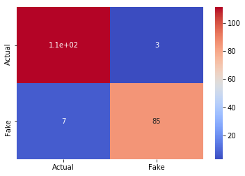

```python
_=sns.heatmap(confusion_df, cmap='coolwarm', annot=True)
```

We can also visualize the tree output using graphviz

```python
from sklearn.tree import export_graphviz
import graphviz
```

```python
dot_data = export_graphviz(tree, filled=True, rounded=True, feature_names=X_train.columns, out_file=None)
```

```python
graphviz.Source(dot_data)
```

[figure not shown]

## Grid Search

```python
param_grid = [{"max_depth":[3, 4, 5,6,7], "max_features":[2,3,4]}]
```

```python
gs = GridSearchCV(estimator=DecisionTreeRegressor(random_state=123),\
                 param_grid = param_grid,\
                 cv=4)
```

Fitting the model to training set

```python
gs.fit(X_train, Y_train)
```

```
GridSearchCV(cv=4, error_score='raise',
       estimator=DecisionTreeRegressor(criterion='mse', max_depth=None, max_features=None,
           max_leaf_nodes=None, min_impurity_decrease=0.0,
           min_impurity_split=None, min_samples_leaf=1,
           min_samples_split=2, min_weight_fraction_leaf=0.0,
           presort=False, random_state=123, splitter='best'),
       fit_params=None, iid=True, n_jobs=1,
       param_grid=[{'max_depth': [3, 4, 5, 6, 7], 'max_features': [2, 3, 4]}],
       pre_dispatch='2*n_jobs', refit=True, return_train_score='warn',
       scoring=None, verbose=0)
```

```python
gs.best_params_
```

```
{'max_depth': 7, 'max_features': 2}
```

```python
gs.best_score_
```

```
0.9243380856456008
```

```python
gs.best_estimator_
```

```
DecisionTreeRegressor(criterion='mse', max_depth=7, max_features=2,
           max_leaf_nodes=None, min_impurity_decrease=0.0,
           min_impurity_split=None, min_samples_leaf=1,
           min_samples_split=2, min_weight_fraction_leaf=0.0,
           presort=False, random_state=123, splitter='best')
```

```python
predictions = gs.predict(X_test)
```

```python
from sklearn.metrics import mean_absolute_error, r2_score
```

```python
confusion_mat = confusion_matrix(Y_test, predictions)
confusion_df = pd.DataFrame(confusion_mat, index=['Actual','Fake'],\
                            columns=['Actual','Fake'])
```

```python
confusion_df
```

|  | Actual | Fake |
| --- | --- | --- |
| Actual | 113 | 1 |
| Fake | 2 | 90 |

We can see model improved . Only 3 data points are classified wrongly

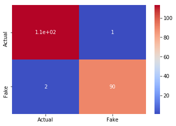

```python
_=sns.heatmap(confusion_df, cmap='coolwarm', annot=True)
```

```python
mean_absolute_error(Y_test, predictions)
```

```
0.014563106796116505
```

```python
r2_score(Y_test, predictions)
```

```
0.9410755148741419
```